# Risk Factor Analysis

## Outcome Variable

**Outcome Variable:** wasted

## Predictor Variables

**Intervention Variable:** enstunt

**Adjustment Set:**

- arm
- sex
- W_mage
- meducyrs
- feducyrs
- vagbrth
- single
- brthmon
- W_parity
- delta_W_mage
- delta_meducyrs
- delta_feducyrs
- delta_vagbrth
- delta_single
- delta_brthmon
- delta_W_parity

## Stratifying Variables

The analysis was stratified on these variable(s):

- agecat
- studyid
- country

## Data Summary

| agecat | studyid | country | enstunt | wasted | n_cell | n |
| --- | --- | --- | --- | --- | --- | --- |
| Birth | ki0047075b-MAL-ED | BANGLADESH | 0 | 0 | 174 | 241 |
| Birth | ki0047075b-MAL-ED | BANGLADESH | 0 | 1 | 36 | 241 |
| Birth | ki0047075b-MAL-ED | BANGLADESH | 1 | 0 | 27 | 241 |
| Birth | ki0047075b-MAL-ED | BANGLADESH | 1 | 1 | 4 | 241 |
| Birth | ki0047075b-MAL-ED | BRAZIL | 0 | 0 | 163 | 183 |
| Birth | ki0047075b-MAL-ED | BRAZIL | 0 | 1 | 6 | 183 |
| Birth | ki0047075b-MAL-ED | BRAZIL | 1 | 0 | 14 | 183 |
| Birth | ki0047075b-MAL-ED | BRAZIL | 1 | 1 | 0 | 183 |
| Birth | ki0047075b-MAL-ED | INDIA | 0 | 0 | 146 | 203 |
| Birth | ki0047075b-MAL-ED | INDIA | 0 | 1 | 27 | 203 |
| Birth | ki0047075b-MAL-ED | INDIA | 1 | 0 | 24 | 203 |
| Birth | ki0047075b-MAL-ED | INDIA | 1 | 1 | 6 | 203 |
| Birth | ki0047075b-MAL-ED | NEPAL | 0 | 0 | 136 | 168 |
| Birth | ki0047075b-MAL-ED | NEPAL | 0 | 1 | 18 | 168 |
| Birth | ki0047075b-MAL-ED | NEPAL | 1 | 0 | 12 | 168 |
| Birth | ki0047075b-MAL-ED | NEPAL | 1 | 1 | 2 | 168 |
| Birth | ki0047075b-MAL-ED | PERU | 0 | 0 | 248 | 279 |
| Birth | ki0047075b-MAL-ED | PERU | 0 | 1 | 5 | 279 |
| Birth | ki0047075b-MAL-ED | PERU | 1 | 0 | 25 | 279 |
| Birth | ki0047075b-MAL-ED | PERU | 1 | 1 | 1 | 279 |
| Birth | ki0047075b-MAL-ED | SOUTH AFRICA | 0 | 0 | 218 | 258 |
| Birth | ki0047075b-MAL-ED | SOUTH AFRICA | 0 | 1 | 14 | 258 |
| Birth | ki0047075b-MAL-ED | SOUTH AFRICA | 1 | 0 | 22 | 258 |
| Birth | ki0047075b-MAL-ED | SOUTH AFRICA | 1 | 1 | 4 | 258 |
| Birth | ki0047075b-MAL-ED | TANZANIA, UNITED REPUBLIC OF | 0 | 0 | 104 | 118 |
| Birth | ki0047075b-MAL-ED | TANZANIA, UNITED REPUBLIC OF | 0 | 1 | 1 | 118 |
| Birth | ki0047075b-MAL-ED | TANZANIA, UNITED REPUBLIC OF | 1 | 0 | 12 | 118 |
| Birth | ki0047075b-MAL-ED | TANZANIA, UNITED REPUBLIC OF | 1 | 1 | 1 | 118 |
| Birth | ki1000108-CMC-V-BCS-2002 | INDIA | 0 | 0 | 65 | 88 |
| Birth | ki1000108-CMC-V-BCS-2002 | INDIA | 0 | 1 | 12 | 88 |

[output cut: 314 more lines]

The following strata were considered:

- agecat: 24 months, studyid: ki0047075b-MAL-ED, country: BANGLADESH
- agecat: 24 months, studyid: ki0047075b-MAL-ED, country: BRAZIL
- agecat: 24 months, studyid: ki0047075b-MAL-ED, country: INDIA
- agecat: 24 months, studyid: ki0047075b-MAL-ED, country: NEPAL
- agecat: 24 months, studyid: ki0047075b-MAL-ED, country: PERU
- agecat: 24 months, studyid: ki0047075b-MAL-ED, country: SOUTH AFRICA
- agecat: 24 months, studyid: ki0047075b-MAL-ED, country: TANZANIA, UNITED REPUBLIC OF
- agecat: 24 months, studyid: ki1000108-CMC-V-BCS-2002, country: INDIA
- agecat: 24 months, studyid: ki1000108-IRC, country: INDIA
- agecat: 24 months, studyid: ki1017093-NIH-Birth, country: BANGLADESH
- agecat: 24 months, studyid: ki1017093b-PROVIDE, country: BANGLADESH
- agecat: 24 months, studyid: ki1017093c-NIH-Crypto, country: BANGLADESH
- agecat: 24 months, studyid: ki1066203-TanzaniaChild2, country: TANZANIA, UNITED REPUBLIC OF
- agecat: 24 months, studyid: ki1101329-Keneba, country: GAMBIA
- agecat: 24 months, studyid: ki1113344-GMS-Nepal, country: NEPAL
- agecat: 24 months, studyid: ki1114097-CMIN, country: BANGLADESH
- agecat: 24 months, studyid: ki1114097-CMIN, country: GUINEA-BISSAU
- agecat: 24 months, studyid: ki1114097-CMIN, country: PERU
- agecat: 24 months, studyid: ki1114097-CONTENT, country: PERU
- agecat: 24 months, studyid: ki1119695-PROBIT, country: BELARUS
- agecat: 24 months, studyid: ki1126311-ZVITAMBO, country: ZIMBABWE
- agecat: 24 months, studyid: ki1135781-COHORTS, country: GUATEMALA
- agecat: 24 months, studyid: ki1135781-COHORTS, country: INDIA
- agecat: 24 months, studyid: ki1135781-COHORTS, country: PHILIPPINES
- agecat: 24 months, studyid: ki1148112-LCNI-5, country: MALAWI
- agecat: 24 months, studyid: kiGH5241-JiVitA-3, country: BANGLADESH
- agecat: 24 months, studyid: kiGH5241-JiVitA-4, country: BANGLADESH
- agecat: 6 months, studyid: ki0047075b-MAL-ED, country: BANGLADESH
- agecat: 6 months, studyid: ki0047075b-MAL-ED, country: BRAZIL
- agecat: 6 months, studyid: ki0047075b-MAL-ED, country: INDIA
- agecat: 6 months, studyid: ki0047075b-MAL-ED, country: NEPAL
- agecat: 6 months, studyid: ki0047075b-MAL-ED, country: PERU
- agecat: 6 months, studyid: ki0047075b-MAL-ED, country: SOUTH AFRICA
- agecat: 6 months, studyid: ki0047075b-MAL-ED, country: TANZANIA, UNITED REPUBLIC OF
- agecat: 6 months, studyid: ki1000108-CMC-V-BCS-2002, country: INDIA
- agecat: 6 months, studyid: ki1000108-IRC, country: INDIA
- agecat: 6 months, studyid: ki1000109-EE, country: PAKISTAN
- agecat: 6 months, studyid: ki1000109-ResPak, country: PAKISTAN
- agecat: 6 months, studyid: ki1000304b-SAS-CompFeed, country: INDIA
- agecat: 6 months, studyid: ki1000304b-SAS-FoodSuppl, country: INDIA
- agecat: 6 months, studyid: ki1017093-NIH-Birth, country: BANGLADESH
- agecat: 6 months, studyid: ki1017093b-PROVIDE, country: BANGLADESH
- agecat: 6 months, studyid: ki1017093c-NIH-Crypto, country: BANGLADESH
- agecat: 6 months, studyid: ki1066203-TanzaniaChild2, country: TANZANIA, UNITED REPUBLIC OF
- agecat: 6 months, studyid: ki1101329-Keneba, country: GAMBIA
- agecat: 6 months, studyid: ki1112895-Guatemala BSC, country: GUATEMALA
- agecat: 6 months, studyid: ki1113344-GMS-Nepal, country: NEPAL
- agecat: 6 months, studyid: ki1114097-CMIN, country: BANGLADESH
- agecat: 6 months, studyid: ki1114097-CMIN, country: BRAZIL
- agecat: 6 months, studyid: ki1114097-CMIN, country: GUINEA-BISSAU
- agecat: 6 months, studyid: ki1114097-CMIN, country: PERU
- agecat: 6 months, studyid: ki1114097-CONTENT, country: PERU
- agecat: 6 months, studyid: ki1119695-PROBIT, country: BELARUS
- agecat: 6 months, studyid: ki1126311-ZVITAMBO, country: ZIMBABWE
- agecat: 6 months, studyid: ki1135781-COHORTS, country: GUATEMALA
- agecat: 6 months, studyid: ki1135781-COHORTS, country: INDIA
- agecat: 6 months, studyid: ki1135781-COHORTS, country: PHILIPPINES
- agecat: 6 months, studyid: ki1148112-LCNI-5, country: MALAWI
- agecat: 6 months, studyid: kiGH5241-JiVitA-3, country: BANGLADESH
- agecat: 6 months, studyid: kiGH5241-JiVitA-4, country: BANGLADESH
- agecat: Birth, studyid: ki0047075b-MAL-ED, country: BANGLADESH
- agecat: Birth, studyid: ki0047075b-MAL-ED, country: BRAZIL
- agecat: Birth, studyid: ki0047075b-MAL-ED, country: INDIA
- agecat: Birth, studyid: ki0047075b-MAL-ED, country: NEPAL
- agecat: Birth, studyid: ki0047075b-MAL-ED, country: PERU
- agecat: Birth, studyid: ki0047075b-MAL-ED, country: SOUTH AFRICA
- agecat: Birth, studyid: ki0047075b-MAL-ED, country: TANZANIA, UNITED REPUBLIC OF
- agecat: Birth, studyid: ki1000108-CMC-V-BCS-2002, country: INDIA
- agecat: Birth, studyid: ki1000108-IRC, country: INDIA
- agecat: Birth, studyid: ki1000109-EE, country: PAKISTAN
- agecat: Birth, studyid: ki1000109-ResPak, country: PAKISTAN
- agecat: Birth, studyid: ki1000304b-SAS-CompFeed, country: INDIA
- agecat: Birth, studyid: ki1017093-NIH-Birth, country: BANGLADESH
- agecat: Birth, studyid: ki1017093c-NIH-Crypto, country: BANGLADESH
- agecat: Birth, studyid: ki1101329-Keneba, country: GAMBIA
- agecat: Birth, studyid: ki1114097-CMIN, country: BANGLADESH
- agecat: Birth, studyid: ki1114097-CMIN, country: BRAZIL
- agecat: Birth, studyid: ki1114097-CMIN, country: PERU
- agecat: Birth, studyid: ki1114097-CONTENT, country: PERU
- agecat: Birth, studyid: ki1119695-PROBIT, country: BELARUS
- agecat: Birth, studyid: ki1126311-ZVITAMBO, country: ZIMBABWE
- agecat: Birth, studyid: ki1135781-COHORTS, country: GUATEMALA
- agecat: Birth, studyid: ki1135781-COHORTS, country: INDIA
- agecat: Birth, studyid: ki1135781-COHORTS, country: PHILIPPINES
- agecat: Birth, studyid: kiGH5241-JiVitA-3, country: BANGLADESH
- agecat: Birth, studyid: kiGH5241-JiVitA-4, country: BANGLADESH

### Dropped Strata

Some strata were dropped due to rare outcomes:

- agecat: Birth, studyid: ki0047075b-MAL-ED, country: BANGLADESH
- agecat: Birth, studyid: ki0047075b-MAL-ED, country: BRAZIL
- agecat: Birth, studyid: ki0047075b-MAL-ED, country: NEPAL
- agecat: Birth, studyid: ki0047075b-MAL-ED, country: PERU
- agecat: Birth, studyid: ki0047075b-MAL-ED, country: SOUTH AFRICA
- agecat: Birth, studyid: ki0047075b-MAL-ED, country: TANZANIA, UNITED REPUBLIC OF
- agecat: Birth, studyid: ki1000108-CMC-V-BCS-2002, country: INDIA
- agecat: Birth, studyid: ki1000108-IRC, country: INDIA
- agecat: Birth, studyid: ki1000109-EE, country: PAKISTAN
- agecat: Birth, studyid: ki1000109-ResPak, country: PAKISTAN
- agecat: Birth, studyid: ki1000304b-SAS-CompFeed, country: INDIA
- agecat: Birth, studyid: ki1017093-NIH-Birth, country: BANGLADESH
- agecat: Birth, studyid: ki1017093c-NIH-Crypto, country: BANGLADESH
- agecat: Birth, studyid: ki1101329-Keneba, country: GAMBIA
- agecat: Birth, studyid: ki1114097-CMIN, country: BANGLADESH
- agecat: Birth, studyid: ki1114097-CMIN, country: BRAZIL
- agecat: Birth, studyid: ki1114097-CMIN, country: PERU
- agecat: Birth, studyid: ki1114097-CONTENT, country: PERU
- agecat: Birth, studyid: ki1119695-PROBIT, country: BELARUS
- agecat: Birth, studyid: ki1135781-COHORTS, country: GUATEMALA
- agecat: 6 months, studyid: ki0047075b-MAL-ED, country: BANGLADESH
- agecat: 6 months, studyid: ki0047075b-MAL-ED, country: BRAZIL
- agecat: 6 months, studyid: ki0047075b-MAL-ED, country: INDIA
- agecat: 6 months, studyid: ki0047075b-MAL-ED, country: NEPAL
- agecat: 6 months, studyid: ki0047075b-MAL-ED, country: PERU
- agecat: 6 months, studyid: ki0047075b-MAL-ED, country: SOUTH AFRICA
- agecat: 6 months, studyid: ki0047075b-MAL-ED, country: TANZANIA, UNITED REPUBLIC OF
- agecat: 6 months, studyid: ki1066203-TanzaniaChild2, country: TANZANIA, UNITED REPUBLIC OF
- agecat: 6 months, studyid: ki1112895-Guatemala BSC, country: GUATEMALA
- agecat: 6 months, studyid: ki1114097-CMIN, country: BRAZIL
- agecat: 6 months, studyid: ki1114097-CMIN, country: PERU
- agecat: 6 months, studyid: ki1114097-CONTENT, country: PERU
- agecat: 6 months, studyid: ki1119695-PROBIT, country: BELARUS
- agecat: 24 months, studyid: ki0047075b-MAL-ED, country: BANGLADESH
- agecat: 24 months, studyid: ki0047075b-MAL-ED, country: BRAZIL
- agecat: 24 months, studyid: ki0047075b-MAL-ED, country: NEPAL
- agecat: 24 months, studyid: ki0047075b-MAL-ED, country: PERU
- agecat: 24 months, studyid: ki0047075b-MAL-ED, country: SOUTH AFRICA
- agecat: 24 months, studyid: ki0047075b-MAL-ED, country: TANZANIA, UNITED REPUBLIC OF
- agecat: 24 months, studyid: ki1066203-TanzaniaChild2, country: TANZANIA, UNITED REPUBLIC OF
- agecat: 24 months, studyid: ki1114097-CMIN, country: PERU
- agecat: 24 months, studyid: ki1114097-CONTENT, country: PERU
- agecat: 24 months, studyid: ki1119695-PROBIT, country: BELARUS
- agecat: 24 months, studyid: ki1148112-LCNI-5, country: MALAWI

## Methods Detail

We’re interested in the causal parameters $E[Y_a]$ for all values of $a \in \mathcal{A}$. These parameters represent the mean outcome if, possibly contrary to fact, we intervened to set all units to have $A=a$. Under the randomization and positivity assumptions, these are identified by the statistical parameters $\psi_a=E_W[E_{Y|A,W}(Y|A=a,W)]$. In addition, we’re interested in the mean of $Y$, $E[Y]$ under no intervention (the observed mean). We will estimate these parameters by using SuperLearner to fit the relevant likelihood factors – $E_{Y|A,W}(Y|A=a,W)$ and $p(A=a|W)$, and then updating our likelihood fit using a joint TMLE.

For unadjusted analyses ($W=\{\}$), initial likelihoods were estimated using Lrnr_glm to estimate the simple $E(Y|A)$ and Lrnr_mean to estimate $p(A)$. For adjusted analyses, a small library containing Lrnr_glmnet, Lrnr_xgboost, and Lrnr_mean was used.

Having estimated these parameters, we will then use the delta method to estimate relative risks and attributable risks relative to a prespecified baseline level of $A$.

# Results Detail

## Results Plots

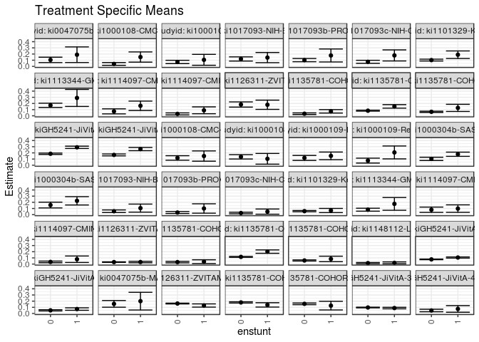

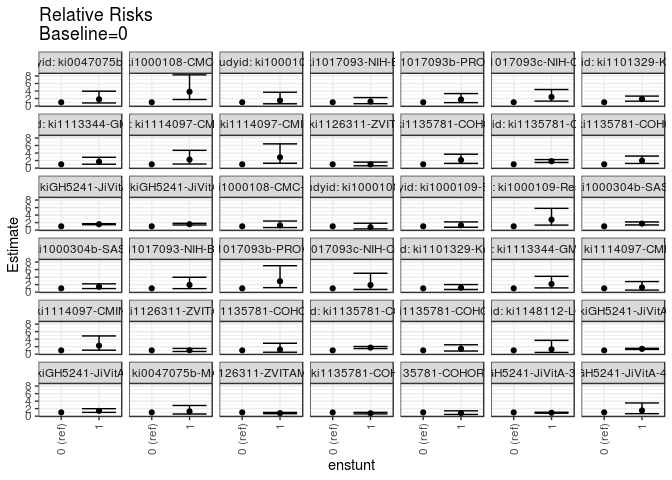

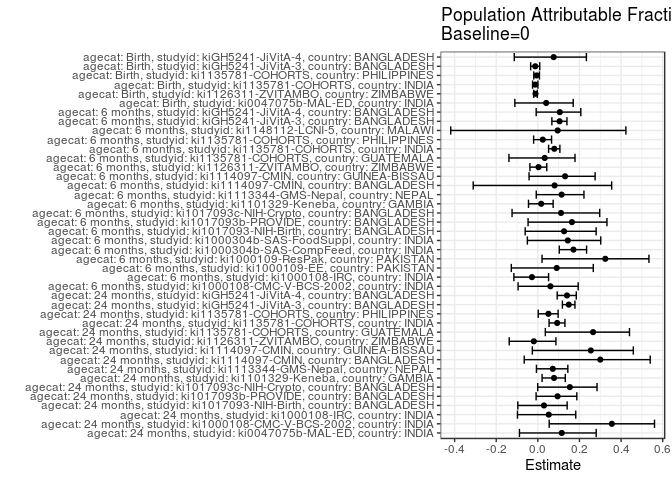

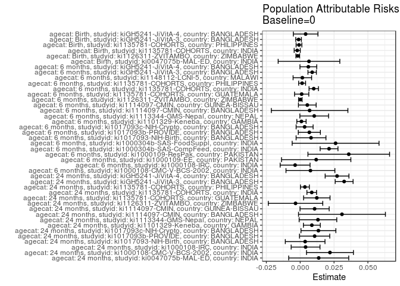

## Results Table

### Parameter: TSM

| agecat | studyid | country | intervention_level | baseline_level | estimate | ci_lower | ci_upper |
| --- | --- | --- | --- | --- | --- | --- | --- |
| Birth | ki0047075b-MAL-ED | INDIA | 0 | NA | 0.1560694 | 0.1018556 | 0.2102831 |
| Birth | ki0047075b-MAL-ED | INDIA | 1 | NA | 0.2000000 | 0.0565106 | 0.3434894 |
| Birth | ki1126311-ZVITAMBO | ZIMBABWE | 0 | NA | 0.1612893 | 0.1547663 | 0.1678123 |
| Birth | ki1126311-ZVITAMBO | ZIMBABWE | 1 | NA | 0.1294436 | 0.1034552 | 0.1554321 |
| Birth | ki1135781-COHORTS | INDIA | 0 | NA | 0.1791636 | 0.1693014 | 0.1890258 |
| Birth | ki1135781-COHORTS | INDIA | 1 | NA | 0.1391529 | 0.1038815 | 0.1744243 |
| Birth | ki1135781-COHORTS | PHILIPPINES | 0 | NA | 0.1564719 | 0.1430412 | 0.1699026 |
| Birth | ki1135781-COHORTS | PHILIPPINES | 1 | NA | 0.1272223 | 0.0572808 | 0.1971637 |
| Birth | kiGH5241-JiVitA-3 | BANGLADESH | 0 | NA | 0.0970624 | 0.0913611 | 0.1027637 |
| Birth | kiGH5241-JiVitA-3 | BANGLADESH | 1 | NA | 0.0880663 | 0.0760157 | 0.1001170 |
| Birth | kiGH5241-JiVitA-4 | BANGLADESH | 0 | NA | 0.0486957 | 0.0283268 | 0.0690645 |
| Birth | kiGH5241-JiVitA-4 | BANGLADESH | 1 | NA | 0.0740741 | 0.0206143 | 0.1275338 |
| 6 months | ki1000108-CMC-V-BCS-2002 | INDIA | 0 | NA | 0.1174377 | 0.0806145 | 0.1542609 |
| 6 months | ki1000108-CMC-V-BCS-2002 | INDIA | 1 | NA | 0.1487939 | 0.0657508 | 0.2318369 |
| 6 months | ki1000108-IRC | INDIA | 0 | NA | 0.1361111 | 0.1006457 | 0.1715766 |
| 6 months | ki1000108-IRC | INDIA | 1 | NA | 0.1041667 | 0.0176423 | 0.1906910 |
| 6 months | ki1000109-EE | PAKISTAN | 0 | NA | 0.1185135 | 0.0781030 | 0.1589240 |
| 6 months | ki1000109-EE | PAKISTAN | 1 | NA | 0.1516438 | 0.0890907 | 0.2141970 |
| 6 months | ki1000109-ResPak | PAKISTAN | 0 | NA | 0.0747693 | 0.0350774 | 0.1144612 |
| 6 months | ki1000109-ResPak | PAKISTAN | 1 | NA | 0.2072174 | 0.1028436 | 0.3115911 |
| 6 months | ki1000304b-SAS-CompFeed | INDIA | 0 | NA | 0.1031326 | 0.0766254 | 0.1296397 |
| 6 months | ki1000304b-SAS-CompFeed | INDIA | 1 | NA | 0.1781350 | 0.1440001 | 0.2122699 |
| 6 months | ki1000304b-SAS-FoodSuppl | INDIA | 0 | NA | 0.1554380 | 0.1086889 | 0.2021871 |
| 6 months | ki1000304b-SAS-FoodSuppl | INDIA | 1 | NA | 0.2240212 | 0.1567764 | 0.2912660 |
| 6 months | ki1017093-NIH-Birth | BANGLADESH | 0 | NA | 0.0554324 | 0.0342944 | 0.0765704 |
| 6 months | ki1017093-NIH-Birth | BANGLADESH | 1 | NA | 0.1058824 | 0.0404107 | 0.1713540 |
| 6 months | ki1017093b-PROVIDE | BANGLADESH | 0 | NA | 0.0344828 | 0.0188164 | 0.0501491 |
| 6 months | ki1017093b-PROVIDE | BANGLADESH | 1 | NA | 0.1000000 | 0.0240256 | 0.1759744 |
| 6 months | ki1017093c-NIH-Crypto | BANGLADESH | 0 | NA | 0.0261011 | 0.0134710 | 0.0387313 |
| 6 months | ki1017093c-NIH-Crypto | BANGLADESH | 1 | NA | 0.0490196 | 0.0070898 | 0.0909494 |

[output cut: 54 more lines]

### Parameter: E(Y)

| agecat | studyid | country | intervention_level | baseline_level | estimate | ci_lower | ci_upper |
| --- | --- | --- | --- | --- | --- | --- | --- |
| Birth | ki0047075b-MAL-ED | INDIA | NA | NA | 0.1625616 | 0.1116803 | 0.2134428 |
| Birth | ki1126311-ZVITAMBO | ZIMBABWE | NA | NA | 0.1594921 | 0.1531776 | 0.1658066 |
| Birth | ki1135781-COHORTS | INDIA | NA | NA | 0.1769740 | 0.1674681 | 0.1864799 |
| Birth | ki1135781-COHORTS | PHILIPPINES | NA | NA | 0.1555709 | 0.1423748 | 0.1687670 |
| Birth | kiGH5241-JiVitA-3 | BANGLADESH | NA | NA | 0.0958686 | 0.0906699 | 0.1010673 |
| Birth | kiGH5241-JiVitA-4 | BANGLADESH | NA | NA | 0.0527086 | 0.0336587 | 0.0717585 |
| 6 months | ki1000108-CMC-V-BCS-2002 | INDIA | NA | NA | 0.1250000 | 0.0911644 | 0.1588356 |
| 6 months | ki1000108-IRC | INDIA | NA | NA | 0.1323529 | 0.0994307 | 0.1652752 |
| 6 months | ki1000109-EE | PAKISTAN | NA | NA | 0.1303191 | 0.0962457 | 0.1643926 |
| 6 months | ki1000109-ResPak | PAKISTAN | NA | NA | 0.1106383 | 0.0704470 | 0.1508296 |
| 6 months | ki1000304b-SAS-CompFeed | INDIA | NA | NA | 0.1244378 | 0.0992652 | 0.1496104 |
| 6 months | ki1000304b-SAS-FoodSuppl | INDIA | NA | NA | 0.1815789 | 0.1427684 | 0.2203895 |
| 6 months | ki1017093-NIH-Birth | BANGLADESH | NA | NA | 0.0634328 | 0.0427791 | 0.0840865 |
| 6 months | ki1017093b-PROVIDE | BANGLADESH | NA | NA | 0.0412371 | 0.0250690 | 0.0574052 |
| 6 months | ki1017093c-NIH-Crypto | BANGLADESH | NA | NA | 0.0293706 | 0.0169860 | 0.0417552 |
| 6 months | ki1101329-Keneba | GAMBIA | NA | NA | 0.0579225 | 0.0479029 | 0.0679420 |
| 6 months | ki1113344-GMS-Nepal | NEPAL | NA | NA | 0.0905861 | 0.0668565 | 0.1143158 |
| 6 months | ki1114097-CMIN | BANGLADESH | NA | NA | 0.0864198 | 0.0510184 | 0.1218211 |
| 6 months | ki1114097-CMIN | GUINEA-BISSAU | NA | NA | 0.0400471 | 0.0268506 | 0.0532437 |
| 6 months | ki1126311-ZVITAMBO | ZIMBABWE | NA | NA | 0.0320668 | 0.0282681 | 0.0358654 |
| 6 months | ki1135781-COHORTS | GUATEMALA | NA | NA | 0.0332295 | 0.0219033 | 0.0445557 |
| 6 months | ki1135781-COHORTS | INDIA | NA | NA | 0.1262774 | 0.1184108 | 0.1341439 |
| 6 months | ki1135781-COHORTS | PHILIPPINES | NA | NA | 0.0594974 | 0.0505830 | 0.0684118 |
| 6 months | ki1148112-LCNI-5 | MALAWI | NA | NA | 0.0166865 | 0.0080138 | 0.0253592 |
| 6 months | kiGH5241-JiVitA-3 | BANGLADESH | NA | NA | 0.0846640 | 0.0798626 | 0.0894653 |
| 6 months | kiGH5241-JiVitA-4 | BANGLADESH | NA | NA | 0.0569005 | 0.0480577 | 0.0657432 |
| 24 months | ki0047075b-MAL-ED | INDIA | NA | NA | 0.1189427 | 0.0767376 | 0.1611478 |
| 24 months | ki1000108-CMC-V-BCS-2002 | INDIA | NA | NA | 0.0618280 | 0.0373207 | 0.0863352 |
| 24 months | ki1000108-IRC | INDIA | NA | NA | 0.0757946 | 0.0501131 | 0.1014762 |
| 24 months | ki1017093-NIH-Birth | BANGLADESH | NA | NA | 0.1238318 | 0.0925894 | 0.1550741 |
| 24 months | ki1017093b-PROVIDE | BANGLADESH | NA | NA | 0.1124567 | 0.0866788 | 0.1382347 |
| 24 months | ki1017093c-NIH-Crypto | BANGLADESH | NA | NA | 0.0875486 | 0.0630907 | 0.1120065 |
| 24 months | ki1101329-Keneba | GAMBIA | NA | NA | 0.1106605 | 0.0958563 | 0.1254646 |
| 24 months | ki1113344-GMS-Nepal | NEPAL | NA | NA | 0.1827309 | 0.1487560 | 0.2167058 |
| 24 months | ki1114097-CMIN | BANGLADESH | NA | NA | 0.1028807 | 0.0646041 | 0.1411572 |
| 24 months | ki1114097-CMIN | GUINEA-BISSAU | NA | NA | 0.0417423 | 0.0250277 | 0.0584569 |
| 24 months | ki1126311-ZVITAMBO | ZIMBABWE | NA | NA | 0.1796690 | 0.1430402 | 0.2162979 |
| 24 months | ki1135781-COHORTS | GUATEMALA | NA | NA | 0.0462107 | 0.0336957 | 0.0587258 |
| 24 months | ki1135781-COHORTS | INDIA | NA | NA | 0.0916651 | 0.0838893 | 0.0994409 |
| 24 months | ki1135781-COHORTS | PHILIPPINES | NA | NA | 0.0681911 | 0.0582056 | 0.0781766 |
| 24 months | kiGH5241-JiVitA-3 | BANGLADESH | NA | NA | 0.2182959 | 0.2084450 | 0.2281469 |
| 24 months | kiGH5241-JiVitA-4 | BANGLADESH | NA | NA | 0.1942978 | 0.1810880 | 0.2075076 |

### Parameter: RR

| agecat | studyid | country | intervention_level | baseline_level | estimate | ci_lower | ci_upper |
| --- | --- | --- | --- | --- | --- | --- | --- |
| Birth | ki0047075b-MAL-ED | INDIA | 0 | 0 | 1.0000000 | 1.0000000 | 1.000000 |
| Birth | ki0047075b-MAL-ED | INDIA | 1 | 0 | 1.2814815 | 0.5774691 | 2.843780 |
| Birth | ki1126311-ZVITAMBO | ZIMBABWE | 0 | 0 | 1.0000000 | 1.0000000 | 1.000000 |
| Birth | ki1126311-ZVITAMBO | ZIMBABWE | 1 | 0 | 0.8025556 | 0.6539319 | 0.984958 |
| Birth | ki1135781-COHORTS | INDIA | 0 | 0 | 1.0000000 | 1.0000000 | 1.000000 |
| Birth | ki1135781-COHORTS | INDIA | 1 | 0 | 0.7766808 | 0.5992615 | 1.006627 |
| Birth | ki1135781-COHORTS | PHILIPPINES | 0 | 0 | 1.0000000 | 1.0000000 | 1.000000 |
| Birth | ki1135781-COHORTS | PHILIPPINES | 1 | 0 | 0.8130677 | 0.4661932 | 1.418037 |
| Birth | kiGH5241-JiVitA-3 | BANGLADESH | 0 | 0 | 1.0000000 | 1.0000000 | 1.000000 |
| Birth | kiGH5241-JiVitA-3 | BANGLADESH | 1 | 0 | 0.9073165 | 0.7831010 | 1.051235 |
| Birth | kiGH5241-JiVitA-4 | BANGLADESH | 0 | 0 | 1.0000000 | 1.0000000 | 1.000000 |
| Birth | kiGH5241-JiVitA-4 | BANGLADESH | 1 | 0 | 1.5211640 | 0.6582436 | 3.515325 |
| 6 months | ki1000108-CMC-V-BCS-2002 | INDIA | 0 | 0 | 1.0000000 | 1.0000000 | 1.000000 |
| 6 months | ki1000108-CMC-V-BCS-2002 | INDIA | 1 | 0 | 1.2670022 | 0.6672096 | 2.405982 |
| 6 months | ki1000108-IRC | INDIA | 0 | 0 | 1.0000000 | 1.0000000 | 1.000000 |
| 6 months | ki1000108-IRC | INDIA | 1 | 0 | 0.7653061 | 0.3204521 | 1.827710 |
| 6 months | ki1000109-EE | PAKISTAN | 0 | 0 | 1.0000000 | 1.0000000 | 1.000000 |
| 6 months | ki1000109-EE | PAKISTAN | 1 | 0 | 1.2795490 | 0.7496187 | 2.184105 |
| 6 months | ki1000109-ResPak | PAKISTAN | 0 | 0 | 1.0000000 | 1.0000000 | 1.000000 |
| 6 months | ki1000109-ResPak | PAKISTAN | 1 | 0 | 2.7714234 | 1.3283772 | 5.782083 |
| 6 months | ki1000304b-SAS-CompFeed | INDIA | 0 | 0 | 1.0000000 | 1.0000000 | 1.000000 |
| 6 months | ki1000304b-SAS-CompFeed | INDIA | 1 | 0 | 1.7272431 | 1.3749373 | 2.169821 |
| 6 months | ki1000304b-SAS-FoodSuppl | INDIA | 0 | 0 | 1.0000000 | 1.0000000 | 1.000000 |
| 6 months | ki1000304b-SAS-FoodSuppl | INDIA | 1 | 0 | 1.4412258 | 0.9421893 | 2.204580 |
| 6 months | ki1017093-NIH-Birth | BANGLADESH | 0 | 0 | 1.0000000 | 1.0000000 | 1.000000 |
| 6 months | ki1017093-NIH-Birth | BANGLADESH | 1 | 0 | 1.9101176 | 0.9237568 | 3.949686 |
| 6 months | ki1017093b-PROVIDE | BANGLADESH | 0 | 0 | 1.0000000 | 1.0000000 | 1.000000 |
| 6 months | ki1017093b-PROVIDE | BANGLADESH | 1 | 0 | 2.9000000 | 1.1966037 | 7.028225 |
| 6 months | ki1017093c-NIH-Crypto | BANGLADESH | 0 | 0 | 1.0000000 | 1.0000000 | 1.000000 |
| 6 months | ki1017093c-NIH-Crypto | BANGLADESH | 1 | 0 | 1.8780637 | 0.7029196 | 5.017819 |

[output cut: 54 more lines]

### Parameter: PAR

| agecat | studyid | country | intervention_level | baseline_level | estimate | ci_lower | ci_upper |
| --- | --- | --- | --- | --- | --- | --- | --- |
| Birth | ki0047075b-MAL-ED | INDIA | 0 | NA | 0.0064922 | -0.0162779 | 0.0292623 |
| Birth | ki1126311-ZVITAMBO | ZIMBABWE | 0 | NA | -0.0017972 | -0.0031713 | -0.0004231 |
| Birth | ki1135781-COHORTS | INDIA | 0 | NA | -0.0021896 | -0.0044516 | 0.0000724 |
| Birth | ki1135781-COHORTS | PHILIPPINES | 0 | NA | -0.0009010 | -0.0030215 | 0.0012195 |
| Birth | kiGH5241-JiVitA-3 | BANGLADESH | 0 | NA | -0.0011938 | -0.0032880 | 0.0009004 |
| Birth | kiGH5241-JiVitA-4 | BANGLADESH | 0 | NA | 0.0040130 | -0.0050796 | 0.0131055 |
| 6 months | ki1000108-CMC-V-BCS-2002 | INDIA | 0 | NA | 0.0075623 | -0.0105011 | 0.0256256 |
| 6 months | ki1000108-IRC | INDIA | 0 | NA | -0.0037582 | -0.0148048 | 0.0072884 |
| 6 months | ki1000109-EE | PAKISTAN | 0 | NA | 0.0118057 | -0.0138104 | 0.0374218 |
| 6 months | ki1000109-ResPak | PAKISTAN | 0 | NA | 0.0358690 | 0.0057147 | 0.0660233 |
| 6 months | ki1000304b-SAS-CompFeed | INDIA | 0 | NA | 0.0213052 | 0.0147094 | 0.0279011 |
| 6 months | ki1000304b-SAS-FoodSuppl | INDIA | 0 | NA | 0.0261410 | -0.0059454 | 0.0582274 |
| 6 months | ki1017093-NIH-Birth | BANGLADESH | 0 | NA | 0.0080005 | -0.0030211 | 0.0190220 |
| 6 months | ki1017093b-PROVIDE | BANGLADESH | 0 | NA | 0.0067544 | -0.0014053 | 0.0149140 |
| 6 months | ki1017093c-NIH-Crypto | BANGLADESH | 0 | NA | 0.0032695 | -0.0030052 | 0.0095442 |
| 6 months | ki1101329-Keneba | GAMBIA | 0 | NA | 0.0009344 | -0.0024963 | 0.0043652 |
| 6 months | ki1113344-GMS-Nepal | NEPAL | 0 | NA | 0.0103598 | -0.0002438 | 0.0209633 |
| 6 months | ki1114097-CMIN | BANGLADESH | 0 | NA | 0.0069496 | -0.0213264 | 0.0352255 |
| 6 months | ki1114097-CMIN | GUINEA-BISSAU | 0 | NA | 0.0052412 | -0.0012968 | 0.0117792 |
| 6 months | ki1126311-ZVITAMBO | ZIMBABWE | 0 | NA | 0.0001038 | -0.0011955 | 0.0014031 |
| 6 months | ki1135781-COHORTS | GUATEMALA | 0 | NA | 0.0010910 | -0.0041736 | 0.0063557 |
| 6 months | ki1135781-COHORTS | INDIA | 0 | NA | 0.0100026 | 0.0065309 | 0.0134742 |
| 6 months | ki1135781-COHORTS | PHILIPPINES | 0 | NA | 0.0014144 | -0.0011590 | 0.0039878 |
| 6 months | ki1148112-LCNI-5 | MALAWI | 0 | NA | 0.0015922 | -0.0052488 | 0.0084332 |
| 6 months | kiGH5241-JiVitA-3 | BANGLADESH | 0 | NA | 0.0088379 | 0.0057312 | 0.0119446 |
| 6 months | kiGH5241-JiVitA-4 | BANGLADESH | 0 | NA | 0.0060099 | -0.0001868 | 0.0122067 |
| 24 months | ki0047075b-MAL-ED | INDIA | 0 | NA | 0.0136796 | -0.0085046 | 0.0358638 |
| 24 months | ki1000108-CMC-V-BCS-2002 | INDIA | 0 | NA | 0.0219812 | 0.0046446 | 0.0393178 |
| 24 months | ki1000108-IRC | INDIA | 0 | NA | 0.0039714 | -0.0066759 | 0.0146187 |
| 24 months | ki1017093-NIH-Birth | BANGLADESH | 0 | NA | 0.0036532 | -0.0110035 | 0.0183098 |
| 24 months | ki1017093b-PROVIDE | BANGLADESH | 0 | NA | 0.0106543 | -0.0005247 | 0.0218332 |
| 24 months | ki1017093c-NIH-Crypto | BANGLADESH | 0 | NA | 0.0134676 | 0.0005840 | 0.0263513 |
| 24 months | ki1101329-Keneba | GAMBIA | 0 | NA | 0.0086112 | 0.0023657 | 0.0148566 |
| 24 months | ki1113344-GMS-Nepal | NEPAL | 0 | NA | 0.0131162 | -0.0007767 | 0.0270091 |
| 24 months | ki1114097-CMIN | BANGLADESH | 0 | NA | 0.0308559 | -0.0012420 | 0.0629538 |
| 24 months | ki1114097-CMIN | GUINEA-BISSAU | 0 | NA | 0.0106312 | -0.0001436 | 0.0214060 |
| 24 months | ki1126311-ZVITAMBO | ZIMBABWE | 0 | NA | -0.0034494 | -0.0235717 | 0.0166728 |
| 24 months | ki1135781-COHORTS | GUATEMALA | 0 | NA | 0.0122686 | 0.0024985 | 0.0220387 |
| 24 months | ki1135781-COHORTS | INDIA | 0 | NA | 0.0085149 | 0.0049596 | 0.0120703 |
| 24 months | ki1135781-COHORTS | PHILIPPINES | 0 | NA | 0.0034637 | 0.0001710 | 0.0067563 |
| 24 months | kiGH5241-JiVitA-3 | BANGLADESH | 0 | NA | 0.0324581 | 0.0258503 | 0.0390658 |
| 24 months | kiGH5241-JiVitA-4 | BANGLADESH | 0 | NA | 0.0272179 | 0.0184374 | 0.0359985 |

### Parameter: PAF

| agecat | studyid | country | intervention_level | baseline_level | estimate | ci_lower | ci_upper |
| --- | --- | --- | --- | --- | --- | --- | --- |
| Birth | ki0047075b-MAL-ED | INDIA | 0 | NA | 0.0399369 | -0.1104621 | 0.1699662 |
| Birth | ki1126311-ZVITAMBO | ZIMBABWE | 0 | NA | -0.0112683 | -0.0199119 | -0.0026979 |
| Birth | ki1135781-COHORTS | INDIA | 0 | NA | -0.0123723 | -0.0252245 | 0.0003187 |
| Birth | ki1135781-COHORTS | PHILIPPINES | 0 | NA | -0.0057917 | -0.0195083 | 0.0077404 |
| Birth | kiGH5241-JiVitA-3 | BANGLADESH | 0 | NA | -0.0124526 | -0.0345103 | 0.0091348 |
| Birth | kiGH5241-JiVitA-4 | BANGLADESH | 0 | NA | 0.0761353 | -0.1132346 | 0.2332919 |
| 6 months | ki1000108-CMC-V-BCS-2002 | INDIA | 0 | NA | 0.0604982 | -0.0949955 | 0.1939112 |
| 6 months | ki1000108-IRC | INDIA | 0 | NA | -0.0283951 | -0.1151161 | 0.0515818 |
| 6 months | ki1000109-EE | PAKISTAN | 0 | NA | 0.0905904 | -0.1275007 | 0.2664964 |
| 6 months | ki1000109-ResPak | PAKISTAN | 0 | NA | 0.3242006 | 0.0202028 | 0.5338782 |
| 6 months | ki1000304b-SAS-CompFeed | INDIA | 0 | NA | 0.1712119 | 0.1030506 | 0.2341934 |
| 6 months | ki1000304b-SAS-FoodSuppl | INDIA | 0 | NA | 0.1439649 | -0.0502693 | 0.3022779 |
| 6 months | ki1017093-NIH-Birth | BANGLADESH | 0 | NA | 0.1261250 | -0.0608311 | 0.2801327 |
| 6 months | ki1017093b-PROVIDE | BANGLADESH | 0 | NA | 0.1637931 | -0.0469553 | 0.3321186 |
| 6 months | ki1017093c-NIH-Crypto | BANGLADESH | 0 | NA | 0.1113183 | -0.1239256 | 0.2973243 |
| 6 months | ki1101329-Keneba | GAMBIA | 0 | NA | 0.0161325 | -0.0448600 | 0.0735647 |
| 6 months | ki1113344-GMS-Nepal | NEPAL | 0 | NA | 0.1143635 | -0.0076096 | 0.2215715 |
| 6 months | ki1114097-CMIN | BANGLADESH | 0 | NA | 0.0804163 | -0.3105913 | 0.3547689 |
| 6 months | ki1114097-CMIN | GUINEA-BISSAU | 0 | NA | 0.1308764 | -0.0422604 | 0.2752524 |
| 6 months | ki1126311-ZVITAMBO | ZIMBABWE | 0 | NA | 0.0032377 | -0.0381151 | 0.0429432 |
| 6 months | ki1135781-COHORTS | GUATEMALA | 0 | NA | 0.0328337 | -0.1388794 | 0.1786571 |
| 6 months | ki1135781-COHORTS | INDIA | 0 | NA | 0.0792112 | 0.0516459 | 0.1059753 |
| 6 months | ki1135781-COHORTS | PHILIPPINES | 0 | NA | 0.0237730 | -0.0203175 | 0.0659583 |
| 6 months | ki1148112-LCNI-5 | MALAWI | 0 | NA | 0.0954178 | -0.4186525 | 0.4232069 |
| 6 months | kiGH5241-JiVitA-3 | BANGLADESH | 0 | NA | 0.1043880 | 0.0674236 | 0.1398873 |
| 6 months | kiGH5241-JiVitA-4 | BANGLADESH | 0 | NA | 0.1056217 | -0.0080051 | 0.2064400 |
| 24 months | ki0047075b-MAL-ED | INDIA | 0 | NA | 0.1150097 | -0.0883863 | 0.2803955 |
| 24 months | ki1000108-CMC-V-BCS-2002 | INDIA | 0 | NA | 0.3555220 | 0.0546287 | 0.5606468 |
| 24 months | ki1000108-IRC | INDIA | 0 | NA | 0.0523971 | -0.0979233 | 0.1821366 |
| 24 months | ki1017093-NIH-Birth | BANGLADESH | 0 | NA | 0.0295011 | -0.0962265 | 0.1408088 |
| 24 months | ki1017093b-PROVIDE | BANGLADESH | 0 | NA | 0.0947413 | -0.0083987 | 0.1873320 |
| 24 months | ki1017093c-NIH-Crypto | BANGLADESH | 0 | NA | 0.1538303 | -0.0005415 | 0.2843844 |
| 24 months | ki1101329-Keneba | GAMBIA | 0 | NA | 0.0778161 | 0.0204165 | 0.1318523 |
| 24 months | ki1113344-GMS-Nepal | NEPAL | 0 | NA | 0.0717787 | -0.0067202 | 0.1441566 |
| 24 months | ki1114097-CMIN | BANGLADESH | 0 | NA | 0.2999194 | -0.0655226 | 0.5400258 |
| 24 months | ki1114097-CMIN | GUINEA-BISSAU | 0 | NA | 0.2546860 | -0.0264565 | 0.4588247 |
| 24 months | ki1126311-ZVITAMBO | ZIMBABWE | 0 | NA | -0.0191989 | -0.1375685 | 0.0868538 |
| 24 months | ki1135781-COHORTS | GUATEMALA | 0 | NA | 0.2654924 | 0.0360108 | 0.4403449 |
| 24 months | ki1135781-COHORTS | INDIA | 0 | NA | 0.0928919 | 0.0539630 | 0.1302189 |
| 24 months | ki1135781-COHORTS | PHILIPPINES | 0 | NA | 0.0507933 | 0.0017705 | 0.0974086 |
| 24 months | kiGH5241-JiVitA-3 | BANGLADESH | 0 | NA | 0.1486884 | 0.1180127 | 0.1782971 |
| 24 months | kiGH5241-JiVitA-4 | BANGLADESH | 0 | NA | 0.1400836 | 0.0929773 | 0.1847434 |